# Assignment 2: Clustering gene-expression data

Dieter Haage

November 27, 2018

# ACTIVITY 1: Clustering Cancerous Tissue Samples

*1) Read Data*

```r
data <- read.arff('golub-1999-v1_database.arff') #  load data
```

*2) Separate Data*

```r
Classe <- select(data, Classe) #  separating classes variable from set
sep_data <- data[,-1869]
```

*3) Compute Matrix*

```r
DistMatrix <- dist(sep_data[1:1868]) #  calculate distance matrix
```

*4) Single Linkage*

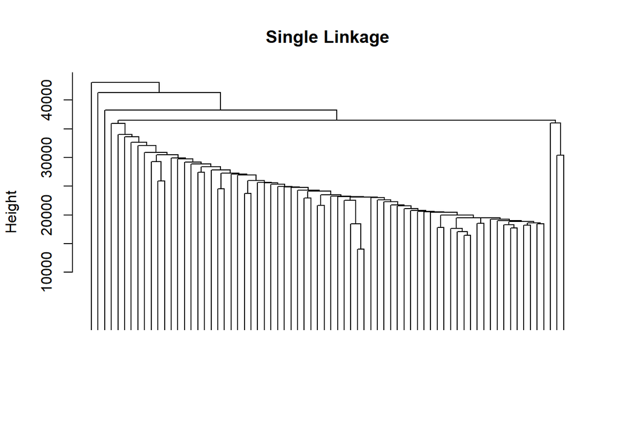

```r
SL_points <- hclust(DistMatrix, method = "single") #  cluster with single linkage
plot(SL_points, main = "Single Linkage", xlab = "", sub = "", hang = -1, labels = FALSE) #  plot without labels
```

*5) Complete Linkage*

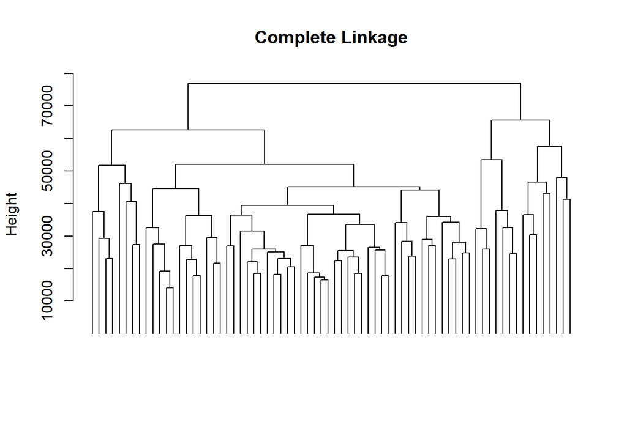

```r
CL_points <- hclust(DistMatrix, method = "complete") #  cluster with complete linkage
plot(CL_points, main = "Complete Linkage", xlab = "", sub = "", hang = -1, labels = FALSE) #  plot without labels
```

*6) Average Linkage*

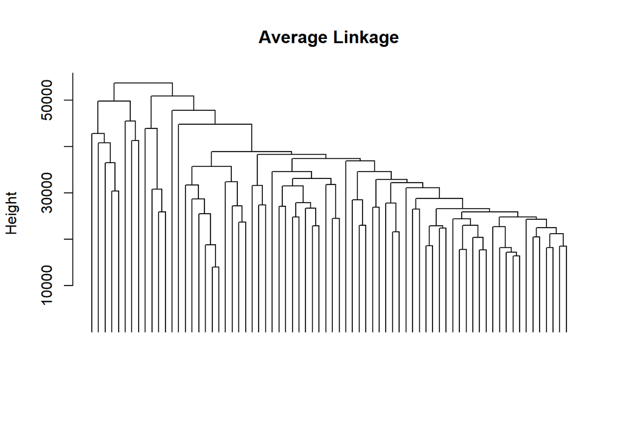

```r
AL_points <- hclust(DistMatrix, method = "average") #  cluster with average linkage
plot(AL_points, main = "Average Linkage", xlab = "", sub ="", hang = -1, labels = FALSE) #  plot without labels
```

*7) Ward’s*

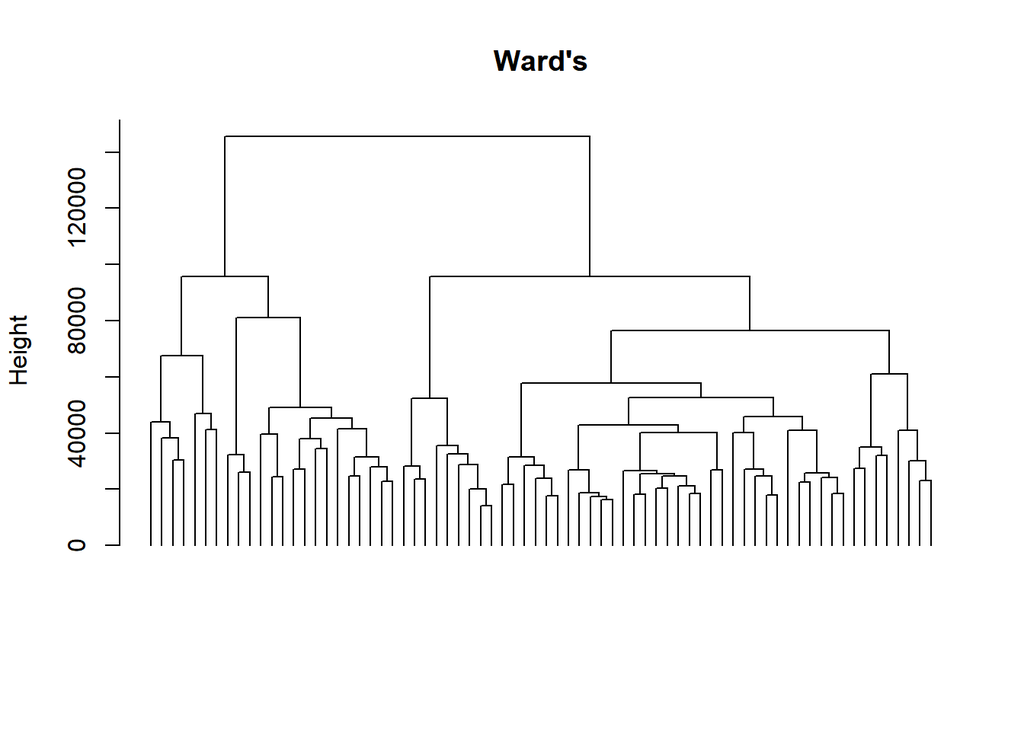

```r
Ward_points <- hclust(DistMatrix, method = "ward.D2") #  cluster with Ward's
plot(Ward_points, main = "Ward's", xlab = "", sub = "", hang = -1, labels = FALSE) #  plot without labels
```

*8) Dendrogram Comparison*

When comparing the dendrograms plotted in items 4 to 7. Some clustering algorithms generate more clear clusters than others.

The algorithms that generated the clearer clusters in this case are Ward’s followed by the Complete Linkage Algorithm.

Unlike the other algorithms, Single Linkage may be experiencing a bridging effect that the others would be less susceptible to, while Average Linkage does not seem to show as much of a clear separation either.

*9) Class Labels 4 to 7 dendrograms*

We will notice that some prominent clusters in the dendrograms below correspond approximately to the classes.

The two sub types of Leukemia are grouped more clearly for Ward’s, Complete, and Average Linkage. The Single Linkage algorithm seems to be able to identify some arbitrarily shaped clusters, however, visually we can see that Single Linkage has a more scattered grouping of the two sub-types of Leukemia, and more outliers within the groups.

This reiterates the notion that the algorithm is more susceptible to noise than the others, and supports the reason as to why there is somewhat of a bridging effect that occurs.

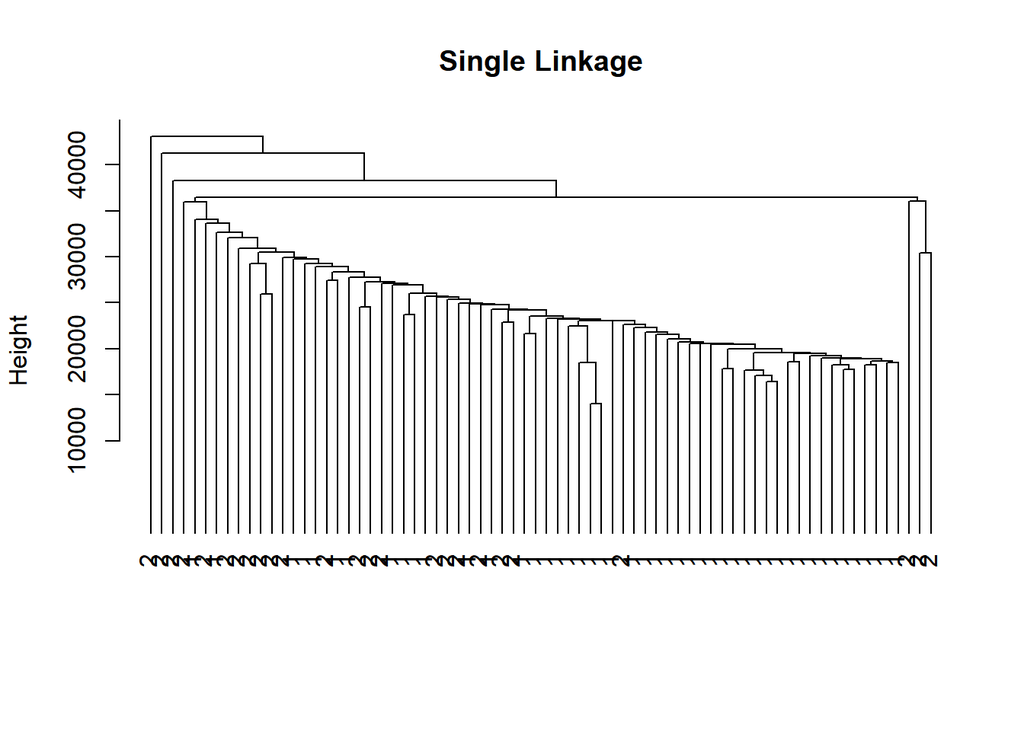

```r
# Single Linkage 4
plot(SL_points, main = "Single Linkage", xlab = "", sub = "", hang = -1, labels = Classe$Classe)
```

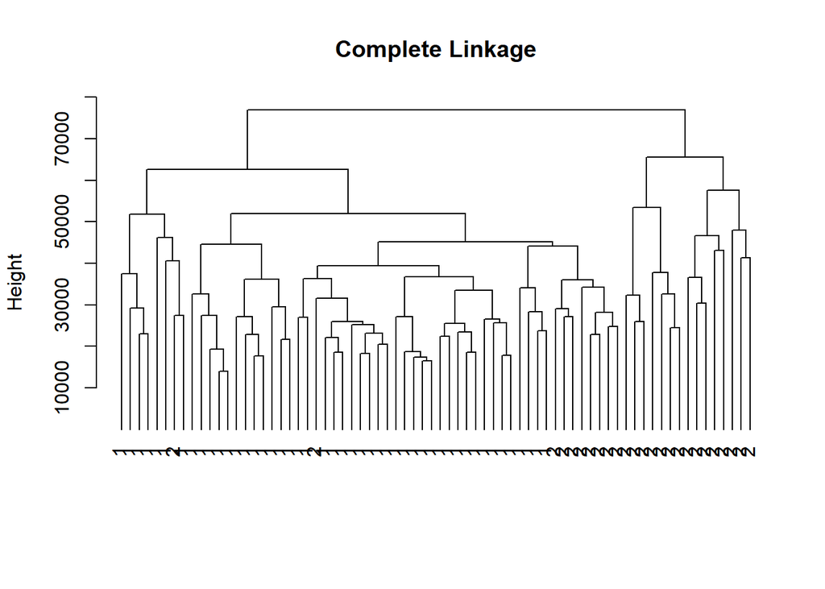

```r
# Complete Linkge 5
plot(CL_points, main = "Complete Linkage", xlab = "", sub = "", hang = -1, labels = Classe$Classe)
```

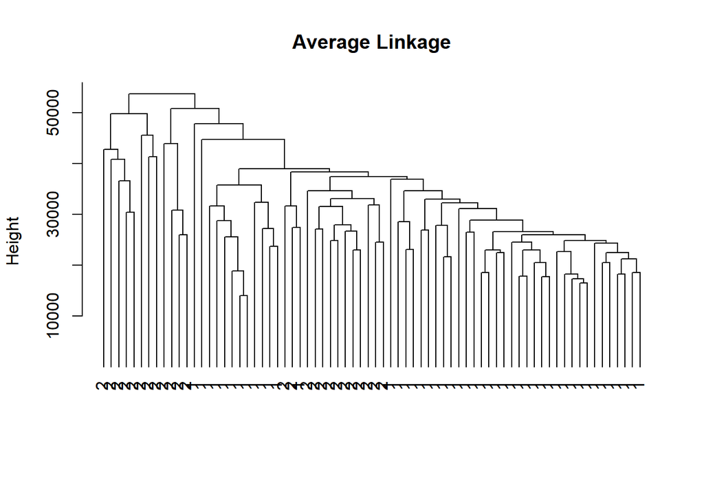

```r
# Average Linkage 6
plot(AL_points, main = "Average Linkage", xlab = "", sub ="", hang = -1, labels = Classe$Classe)
```

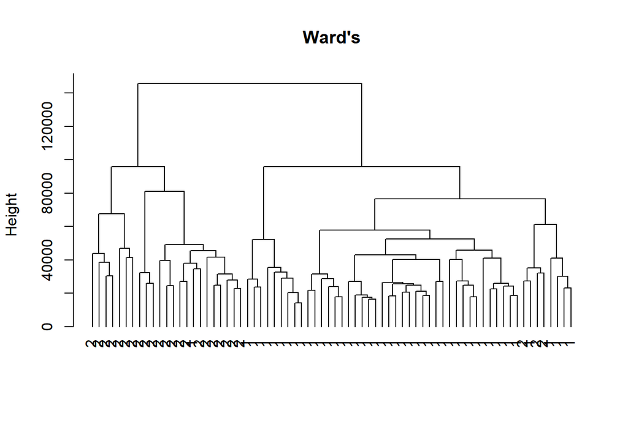

```r
# Wards 7
plot(Ward_points, main = "Ward's", xlab = "", sub = "", hang = -1, labels = Classe$Classe)
```

*10) Normalized Data*

After normalizing the data, we observe very little improvement in the case of Single Linkage. Since normalizing the data should prevent variables with higher value ranges from dominating distance computations, we do see less of a bridging affect in Single Linkage, however there is no improvement in the grouping of the Leukemia sub-types.

When comparing Complete Linkage, once the data has been normalized, we see more of a bridging affect, and a dis improvement in the grouping of the Leukemia sub-types. Since Complete Linkage favors volumetric, globular clusters, by normalizing the data, we see a distortion in the clustering for Complete Linkage.

This could be attributed to the fact that by normalizing the data, the natural differences in variance have been removed, which in turn limits the algorithm in it’s ability categorize variables with wider value ranges as clusters.

We observe a similar case for the Average Linkage algorithm, where there is a distortion in the clustering, and dis improvement in the grouping of the Leukemia sub-types. Ward’s also experiences a similar effect since there is a major dis improvement in the grouping of the sub-types.

Overall, for the purposes of this investigation, it would be more appropriate to make use of Ward’s algorithm with out normalizing the data first.

```r
# Normalize
sep_data <- data[,-1869]
sep_data <- as.data.frame(scale(sep_data))
DistMatrix <- dist(sep_data[1:1868])
```

*Normalized Single Linkage*

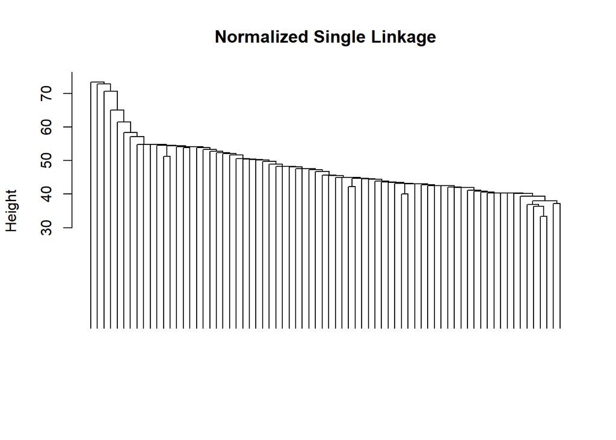

```r
SL_points <- hclust(DistMatrix, method = "single")

plot(SL_points, main = "Normalized Single Linkage", xlab = "", sub = "", hang = -1, labels = FALSE)
```

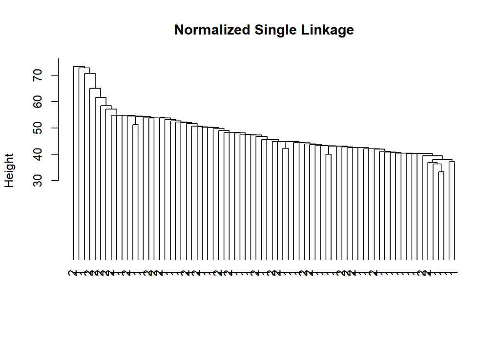

```r
plot(SL_points, main = "Normalized Single Linkage", xlab = "", sub = "", hang = -1, labels = Classe$Classe)
```

*Normalized Complete Linkage*

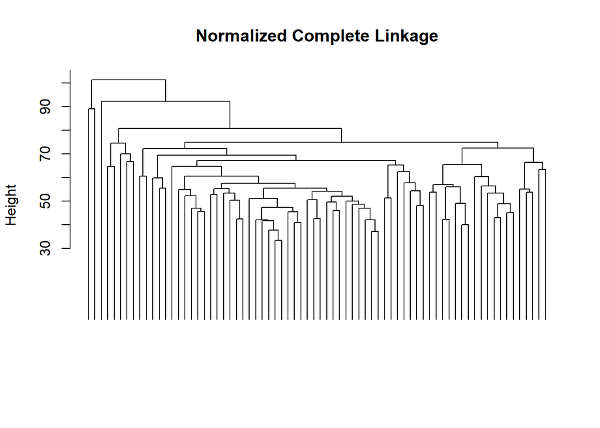

```r
CL_points <- hclust(DistMatrix, method = "complete")

plot(CL_points, main = "Normalized Complete Linkage", xlab = "", sub = "", hang = -1, labels = FALSE)
```

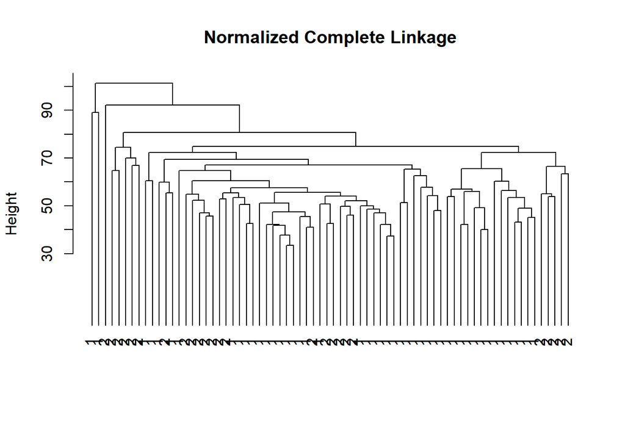

```r
plot(CL_points, main = "Normalized Complete Linkage", xlab = "", sub = "", hang = -1, labels = Classe$Classe)
```

*Normalized Average Linkage*

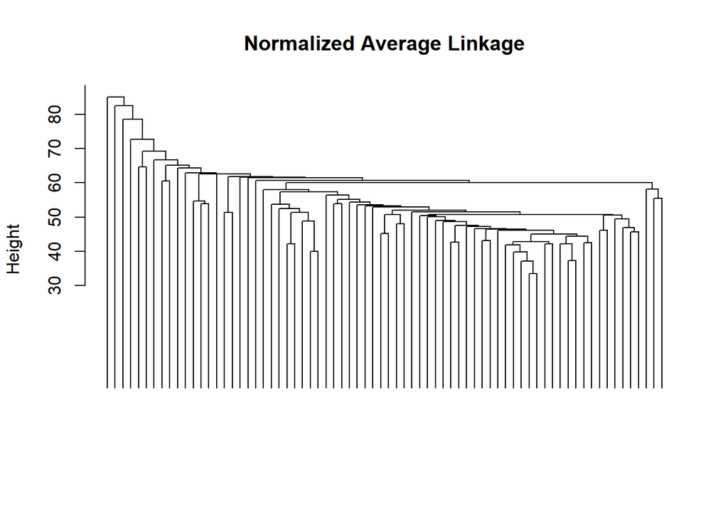

```r
AL_points <- hclust(DistMatrix, method = "average")

plot(AL_points, main = "Normalized Average Linkage", xlab = "", sub ="", hang = -1, labels = FALSE)
```

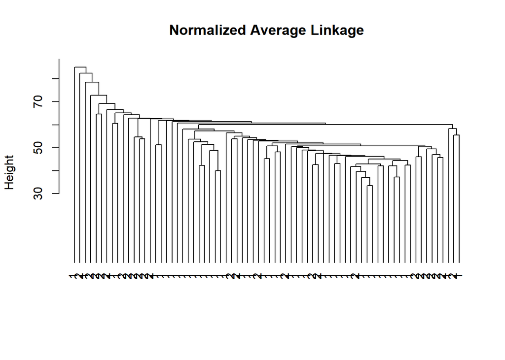

```r
plot(AL_points, main = "Normalized Average Linkage", xlab = "", sub ="", hang = -1, labels = Classe$Classe)
```

*Normalized Ward’s*

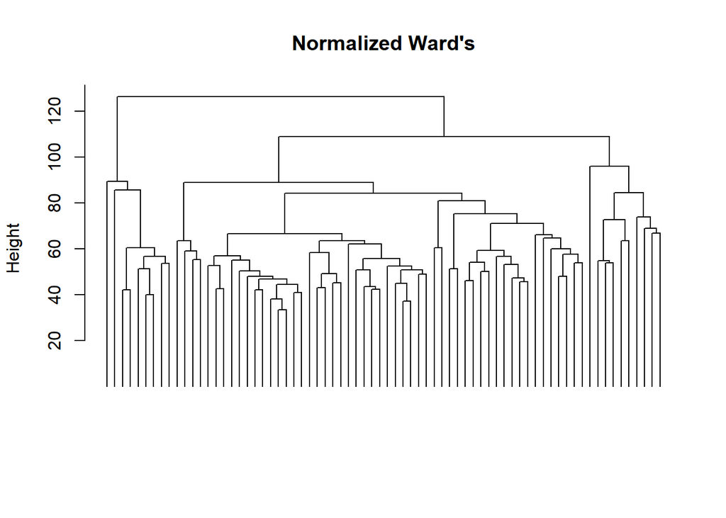

```r
Ward_points <- hclust(DistMatrix, method = "ward.D2")

plot(Ward_points, main = "Normalized Ward's", xlab = "", sub = "", hang = -1, labels = FALSE)
```

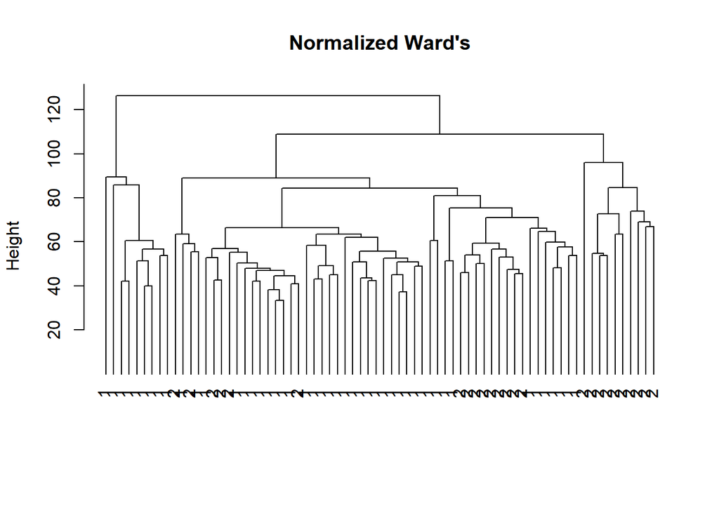

```r
plot(Ward_points, main = "Normalized Ward's", xlab = "", sub = "", hang = -1, labels = Classe$Classe)
```

# ACTIVITY 2: Clustering Genes (PART A)

*11) Read Data*

```r
data <- read.arff('yeast.arff') # read data from ARFF
```

*12) Separate Data*

```r
# Set aside rightmost column (class labels)
Classe <- select(data, Classe)
sep_data <- data[,-21]
SL_points <- sep_data
```

*13) Pearson Dissimilarity*

```r
trans_sep_data <- as.data.frame(t(as.matrix(sep_data))) #  transpose
new_set <- cor(trans_sep_data) #  find correlations of transposed separated data
pearson_diss <- as.matrix(1- new_set) #  pearson dissimilarities
DistMatrix <- as.dist(pearson_diss) #  as distance matrix
```

*14) Dissimilarity Matrix*

Single Linkage seems to be less susceptible to noise in this case, and therefore could also be the reason as why it experiences less of a bridging affect.

Overall there are less scattered groupings, and with Ward’s algorithm already considered as the front runner out of algorithms tested, it has improved even more so. For this investigation, Ward’s algorithm, couple with the use of a Pearson dissimilarity matrix, appears to be the optimal strategy.

*Dissimilarity Single Linkage*

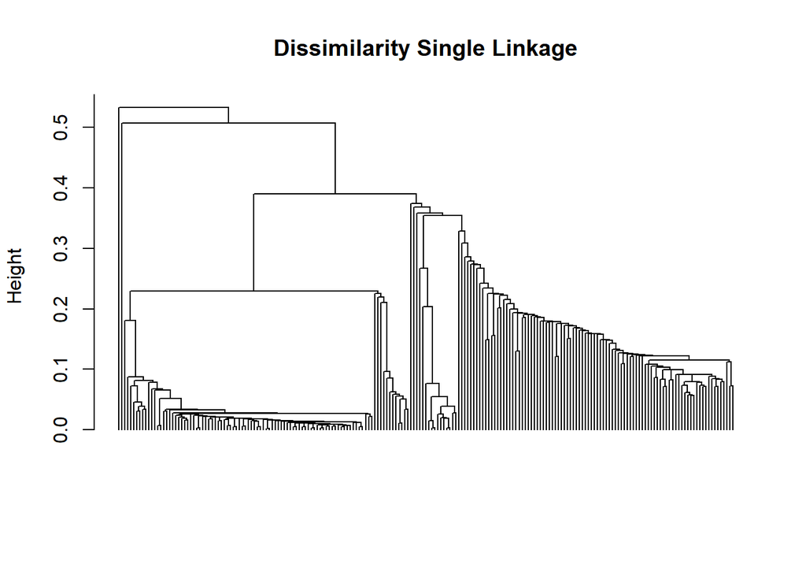

```r
pearson_diss <- hclust(DistMatrix, method = "single")

plot(pearson_diss, main = "Dissimilarity Single Linkage", xlab = "", sub = "", hang = -1, labels = FALSE)
```

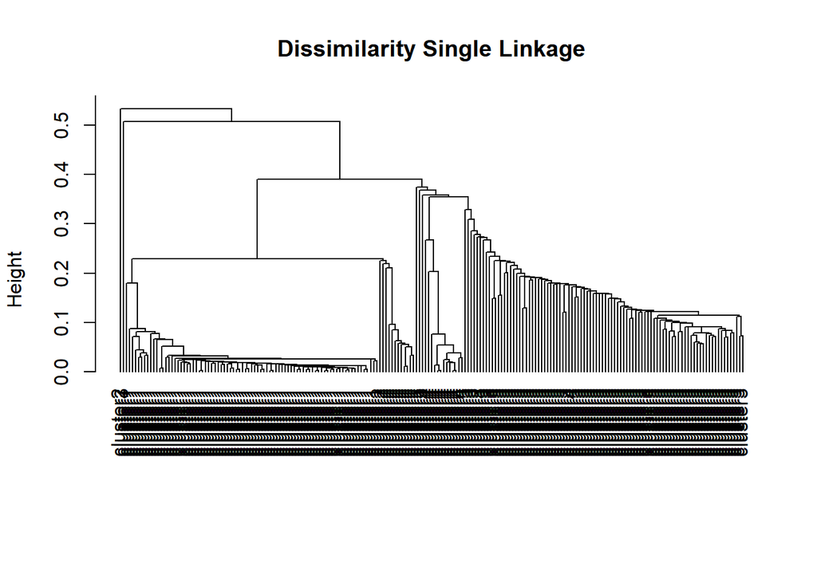

```r
plot(pearson_diss, main = "Dissimilarity Single Linkage", xlab = "", sub = "", hang = -1, labels = Classe$Classe)
```

*Dissimilarity Complete Linkage*

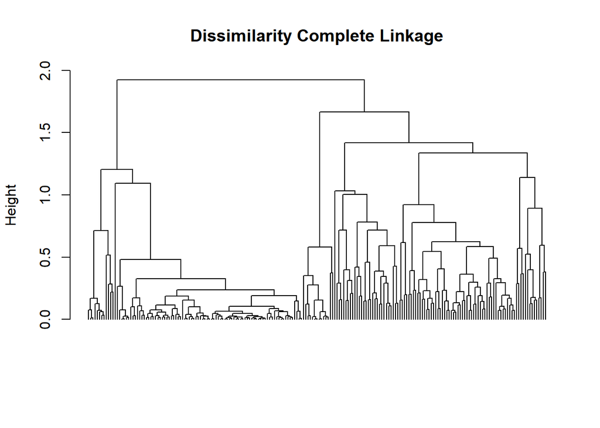

```r
CL_points <- hclust(DistMatrix, method = "complete")

plot(CL_points, main = "Dissimilarity Complete Linkage", xlab = "", sub = "", hang = -1, labels = FALSE)
```

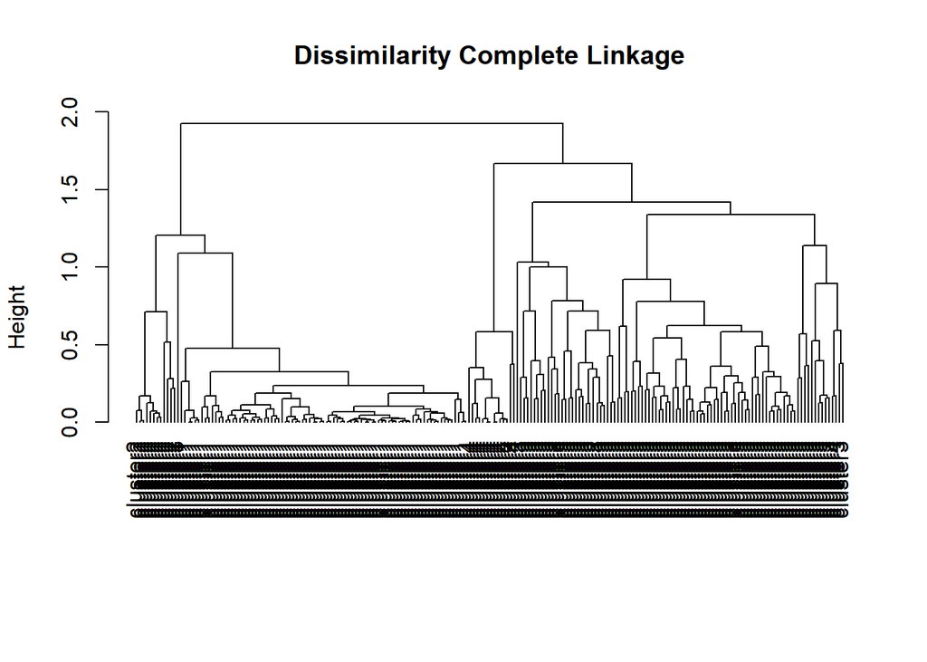

```r
plot(CL_points, main = "Dissimilarity Complete Linkage", xlab = "", sub = "", hang = -1, labels = Classe$Classe)
```

*Dissimilarity Average Linkage*

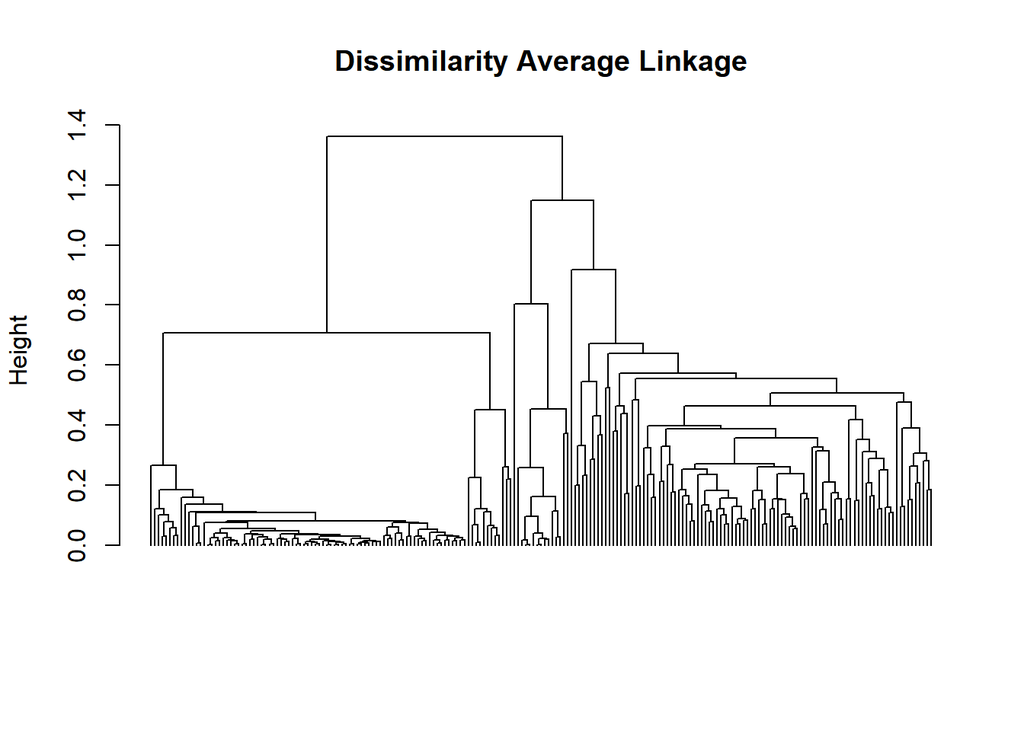

```r
AL_points <- hclust(DistMatrix, method = "average")

plot(AL_points, main = "Dissimilarity Average Linkage", xlab = "", sub ="", hang = -1, labels = FALSE)
```

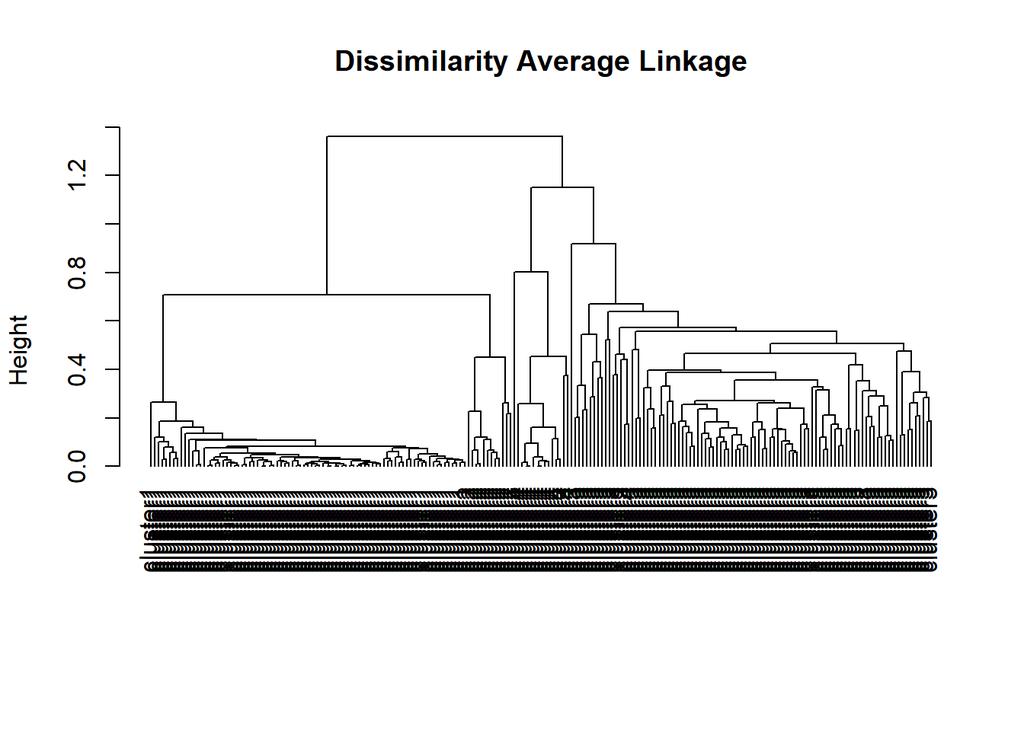

```r
plot(AL_points, main = "Dissimilarity Average Linkage", xlab = "", sub ="", hang = -1, labels = Classe$Classe)
```

*Dissimilarity Ward’s*

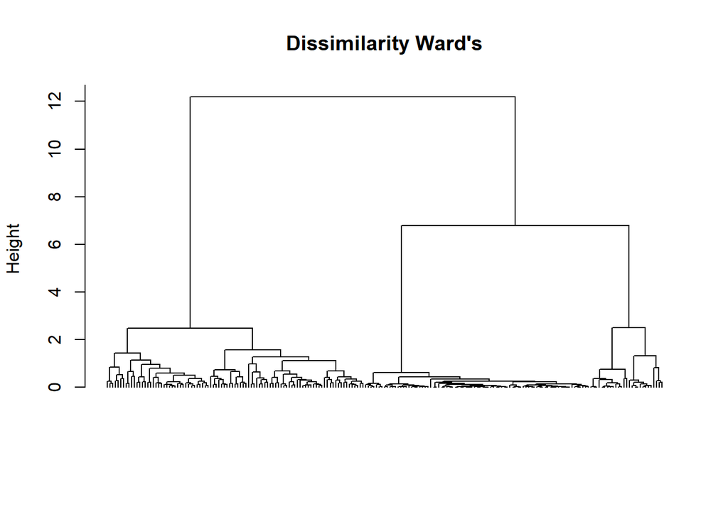

```r
Ward_points <- hclust(DistMatrix, method = "ward.D2")

plot(Ward_points, main = "Dissimilarity Ward's", xlab = "", sub = "", hang = -1, labels = FALSE)
```

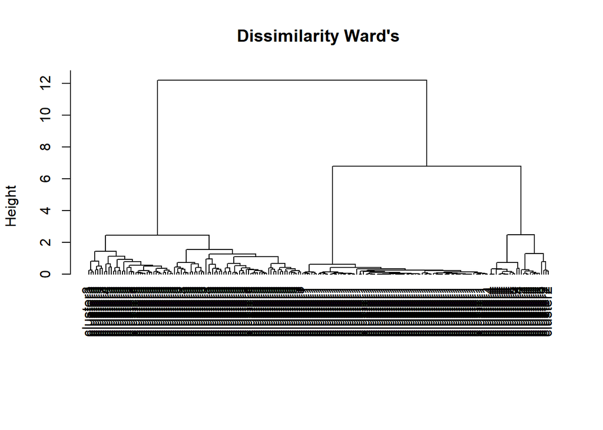

```r
plot(Ward_points, main = "Dissimilarity Ward's", xlab = "", sub = "", hang = -1, labels = Classe$Classe)
```

# ACTIVITY 3: Clustering Genes (PART B)

*15) Rescale Row-wise*

```r
data <- read.arff('yeast.arff') #  Data Set
Classe <- select(data, Classe) #  Separate Data
sep_data <- data[,-21] #  Separate

rescaled <- sep_data/sqrt(sum(sep_data^2)) #  rescale row-wise with magnitude of 1
rescaled_by_row <- rescaled/max(rescaled)
```

*16) Run HDBSCAN (with Euclidean distance)*

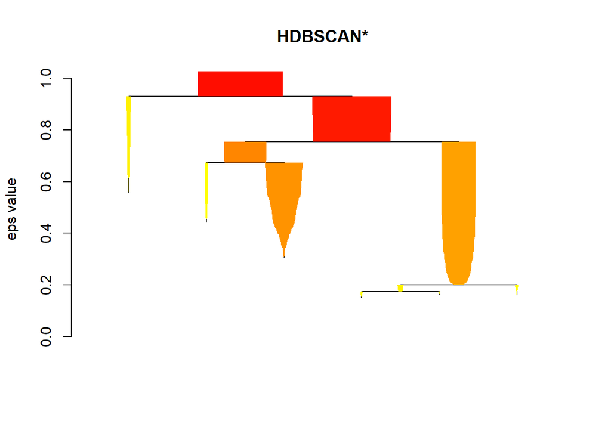

```r
hdbs <- hdbscan(rescaled_by_row , minPts = 5) #  hdbscan min = 5
plot(hdbs) #  plot result without class labels
```

```r
hdbs$hc
```

```
##
## Call:
## hdbscan(x = rescaled_by_row, minPts = 5)
##
## Cluster method   : robust single
## Distance         : mutual reachability
## Number of objects: 205
```

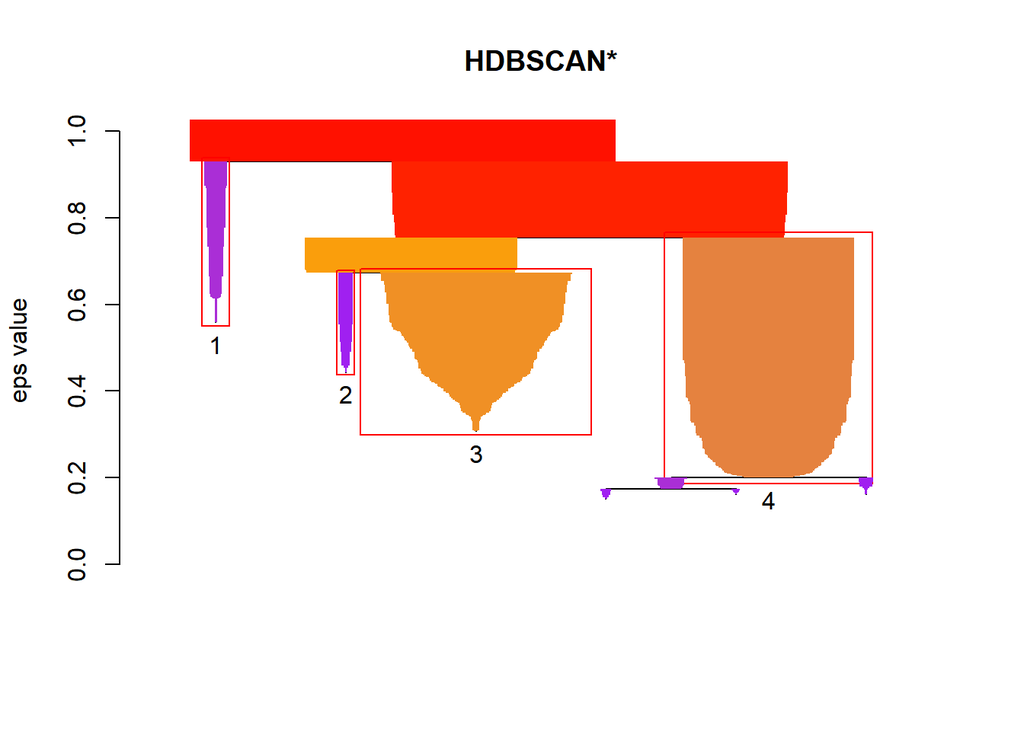

```r
plot(hdbs, scale = 3, gradient = c("purple", "orange", "red"), show_flat = T)  #  clusters
```

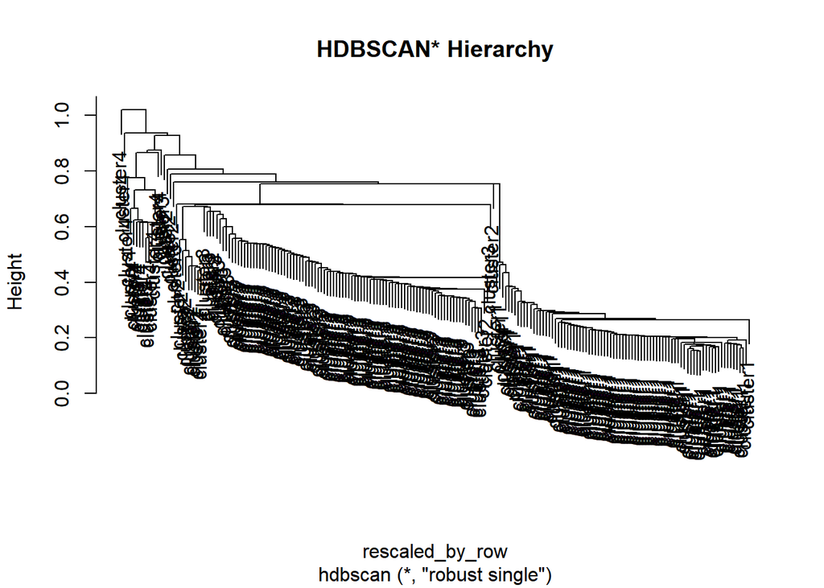

```r
plot(hdbs$hc, main="HDBSCAN* Hierarchy", labels = Classe$Classe) # plot result without class labels
```

*17) Contingency Table*

```r
hdbs # plot contingency table
```

```
## HDBSCAN clustering for 205 objects.
## Parameters: minPts = 5
## The clustering contains 4 cluster(s) and 8 noise points.
##
##  0  1  2  3  4
##  8 12  8 93 84
##
## Available fields: cluster, minPts, cluster_scores,
##                   membership_prob, outlier_scores, hc
```

*18)*

*19)*

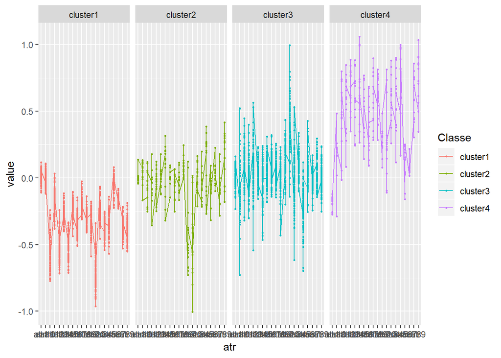

```r
long_DF <- data %>% gather(atr, value , atr1:atr20) #  manipulate frame
ggplot(data = long_DF, mapping = aes(y = value, x = atr ,group = Classe, colour=Classe)) + facet_grid(~Classe) +
   geom_line(size=.5) +
   geom_point(size=.5) # plot
```

*20)*

```r
dataset <- data[,-21]

dataset$new_classes <- as.factor(hdbs$cluster) #label as factors
dataset <- filter(dataset, new_classes != "0") #  Remove 0 Classifications


mapvalues(dataset$new_classes, from = c("2", "1", "4","3"), to = c("1", "2","3","4")) # change values to corresponding
```

```
##   [1] 3 3 3 3 3 3 3 3 3 3 3 3 3 3 3 3 3 3 3 3 3 3 3 3 3 3 3 3 3 3 3 3 3 3 3
##  [36] 3 3 3 3 3 3 3 3 3 3 3 3 3 3 3 3 3 3 3 3 3 3 3 3 3 3 3 3 3 3 3 3 3 3 3
##  [71] 3 3 3 3 3 3 3 3 3 3 3 3 3 1 1 1 1 1 1 1 1 4 4 4 3 4 4 4 4 4 4 4 4 4 4
## [106] 4 4 4 4 4 4 4 4 4 4 4 4 4 4 4 4 4 4 4 4 4 4 4 4 4 4 4 4 4 4 4 4 4 4 4
## [141] 4 4 4 4 4 4 4 4 4 4 4 4 4 4 4 4 4 4 4 4 4 4 4 4 4 4 4 4 4 4 4 4 4 4 4
## [176] 4 4 4 4 4 4 4 4 4 4 2 2 2 2 2 2 2 2 2 2 2 2
## Levels: 0 2 1 4 3
```

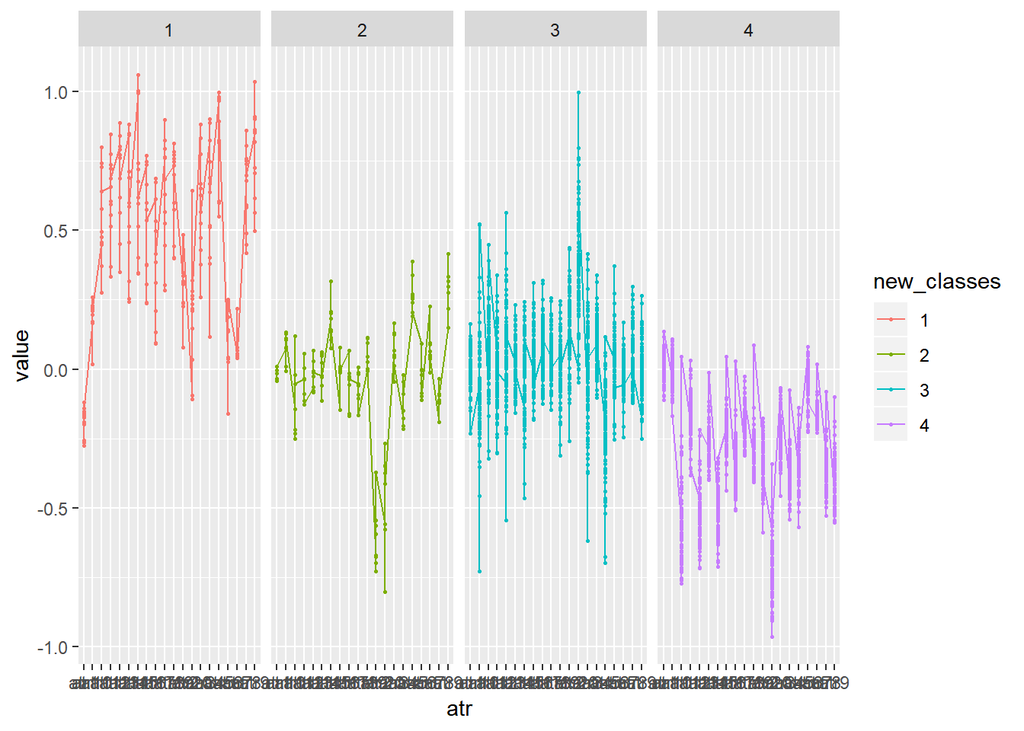

```r
long_DF_2 <- dataset %>% gather(atr, value , atr1:atr20) # manipulate frame
ggplot(data = long_DF_2, mapping = aes(y = value, x = atr ,group = new_classes, colour=new_classes)) + facet_grid(~ new_classes) +
   geom_line(size=.5) +
   geom_point(size=.5) #  plot
```

*21)*

1. The pairs of sub-figures correspond reasonably well to the associated functional category class 2 and 3. The classes 1 and 4 have been classified either as higher or lower values.
2. The contingency table for the functional categories that have genes left unclustered in category 0 were identified as noise, once they were removed we could see more separation between classes for Item 20. The removal of these genes did not necessarily make all the patterns more prominent, however for category 1 there does seem to be a more distinct separation from the other classes. It is possible to say that the noise by HDBSCAN could be seen as outliers.